# Homework_3

1. Question 1: Adversarial Examples & GANs
2. Question 2: A Convolutional Discriminator
3. Question 3: Mode Collapse
4. Question 4: Latent Interpolation

## Setup

If you do not have access to a CUDA-compatible NVIDIA GPU, it is recommended that you run this notebook in [Google Colab](https://colab.research.google.com/). There, you will have the option to enable GPU acceleration with `Runtime` >> `Change runtime type` >> `Hardware accelerator` >> `GPU` >> `Save`. Note that you may have to re-connect or restart the notebook after changing runtime types.

```python
# helper code from the course repository
!git clone https://github.com/interactiveaudiolab/course-deep-learning.git
# install common pacakges used for deep learning
!cd course-deep-learning/ && pip install -r requirements.txt
```

```python
%matplotlib inline
%cd course-deep-learning/

import datetime
import math
import torch
import matplotlib.pyplot as plt
import numpy as np
import IPython.display as ipd
from matplotlib.animation import FuncAnimation
from pathlib import Path
from torch.utils.tensorboard import SummaryWriter
from torchsummary import summary
from tqdm import tqdm

from utils.gan import *
from utils.adversarial_examples import *
```

```
/content/course-deep-learning
```

## Question 1: Adversarial Examples & GANs (four points total)

In [notebook 5](https://github.com/interactiveaudiolab/course-deep-learning/blob/main/notebooks/notebook_5_adversarial_examples.ipynb), we learned how to generate *adversarial examples* by optimizing images so that they would be recognized in a certain way by a neural network. Often, we did so by applying very small *perturbations*, and the resulting adversarial examples looked similar to the original unperturbed images. This begs the question: if we allowed for very large perturbations, would our adversarial examples start to resemble images of our chosen class?

### **1.1**: Generating Adversarial Examples (one point)

First, we'll review the process of generating adversarial examples. **Modify the code below to craft an adversarial examples that is as *imperceptible* as possible while still fooling the given neural network into recognizing the digit 9. Include an image of your final adversarial example using the `plot_mnist()` function provided. Then, briefly explain your modifications below.** Some modifications to consider (these are hints on what to do, not questions to be answered):

- How many iterations will you optimize for?
- Can you use a learning rate to scale your gradient-based updates of the input image?
- Can you somehow "bound" your adversarial perturbation at each iteration?

Feel free to look at [notebook 5](https://github.com/interactiveaudiolab/course-deep-learning/blob/main/notebooks/notebook_5_adversarial_examples.ipynb) for ideas.

### Result with Projected Gradient Descent (PGD) Attack

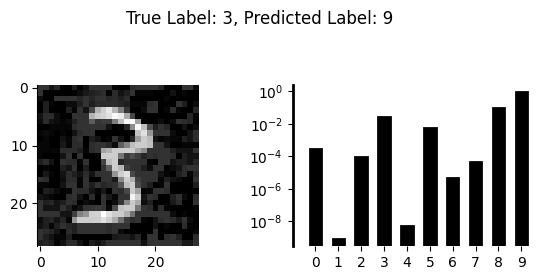

### Result with Langrangian Relaxation

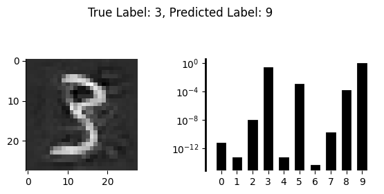

I ended up testing both the PGD attack and the Langrangian Relaxation. I found that with the PGD attack, utilizing clipping was useful in making the end adversarial example look as imperceptible as possible. With lagrangian, I had to adjust the loss function using regularization techniques with the norm, and adjusted the way I update the delta value also based on the norm and the step size I use. I found that the lagrangian relaxation tends to create smoother more similar adversarial examples than with PGD attacks.

#### Starter Code

Modify this code where indicated to craft your adversarial example.

```python
# fix random seed - this makes sure we don't accidentally grab an input
# from the class we are trying to 'impersonate'
torch.manual_seed(0)

# select device
device = torch.device("cuda" if torch.cuda.is_available() else "cpu")

# download MNIST data
mnist_train, mnist_test = load_mnist()

# load neural network classifier
model = MNISTClassifier()
model.to(device)

# load pretrained weights (included with repo)
model.load_state_dict(torch.load('./utils/adversarial_examples/pretrained/mnist_classifier.pt', map_location=device))

# select an input
batch_x, batch_y = next(iter(mnist_test))
x, y = batch_x[1].to(device), batch_y[1].to(device)

# plot original image and the model's prediction (class scores) side-by-side
plot_mnist(x, y, model)

# we want the network to predict the label '9' given our adversarial input, so
# we'll set this as our 'target' when computing our loss and optimizing
target = torch.tensor([9]).to(device)

# our input image; make sure we tell PyTorch to track its gradients
x = x.reshape(1, 1, 28, 28).detach()

# iteratively optimize an additive perturbation to our input
delta = torch.zeros_like(x).requires_grad_(True)

################################################################################
# YOUR MODIFICATIONS CAN START HERE
################################################################################

# learning rate for updates
step_size = 0.1

for i in range(1, 25):

    # clear gradients each step
    delta.grad = None

    # compute model's class scores given perturbed input (x + delta)
    outputs = model(x + delta)

    loss = torch.nn.functional.nll_loss(outputs, target)

    # Lagrangian
    # loss = torch.nn.functional.nll_loss(outputs, target) + 0.3 * delta.norm()

    # compute gradient of loss w.r.t. our perturbation
    loss.backward()
    grad = delta.grad.detach()

    # update our perturbation to descend the loss
    with torch.no_grad():
        # delta -= (grad/(grad.norm() + 1e-12)) * step_size # lagrangian
        delta -= torch.sign(grad) * step_size
        delta.clip_(min=-0.4, max=0.4)

# plot adversarial example and corresponding prediction
# plot_mnist(x + delta.detach(), y, model)
```

### **1.2**: Unbounded Adversarial Examples (one point)

Next, we'll remove our "imperceptibility" constraint and try to craft an adversarial perturbation *so large that the perturbed image looks to a human like an instance of the target class*. That is, we'll try to optimize an image of one class to look like an image from another class. **Modify the starter code above to craft a *large* adversarial perturbation that makes the classifier *as confident as possible* that it is seeing the target class (9). Include an image of your final adversarial example below.**

Looks to a human like a 9, but it is in fact a 3.

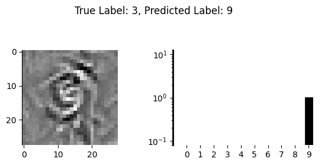

### **1.3**: Free Response (two points)

A young researcher is studying adversarial examples and GANs, and notes that both topics involve using the gradients of a neural network to craft inputs that the network classifies in a certain way. The researcher therefore posits that a simple alternative to GANs would be to first train a classifier to recognize images of the classes one wants to generate (e.g. handwritten digits), and then to optimize a random noise image just like an adversarial example until the classifier recognizes it as the desired class. **Is it likely this approach will yield images that look like clear examples of the desired class? Why or why not? Support your answer with results. You should do something like question 1.2 above, but try it repeatedly (maybe 10 or more times), each time from a different image comprised of random noise.**

No, I'd argue that this approach would not yield images that look like clear examples of the desired class. Similar to what was discussed in the textbook and in class, human beings have a difficult time understanding high dimensional spaces. This being said, our model may be able to classify things as a certain class, but because the training was done separately and not together, the model is not as robust to adversarial examples. For example, this young researcher's model may predict a nine in the example photo I show below, however, to a human being, it is very clear that this is not a nine -- but the computer doesn't know that.

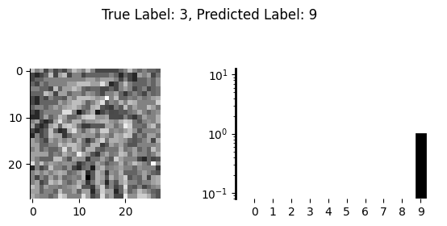

## Question 2: A Convolutional Discriminator (three points total)

We've previously seen how convolutional neural networks can outperform their fully-connected counterparts by leveraging the local spatial structure inerent to image data. This begs the question: could we strenghten our GAN by using convolutions? We'll put this hypothesis to the test with a new dataset, [FashionMNIST](https://github.com/zalandoresearch/fashion-mnist), that consists of articles of clothing rather than handwritten digits. We'll start by looking at some of the convolutional arithmetic that motivates the design of our discriminator.

### 2.1: Building a Convolutional Discriminator (one point)

We will structure our discriminator as a sequence of four convolutional layers, using the `torch.nn.Conv2d` module. Each convolutional layer will take a tensor of shape `(batch_size, in_channels, in_height, in_width)` and output a tensor of shape `(batch_size, out_channels, out_height, out_width)`. The first three layers will progressively *downsample* along the spatial dimensions (height and width) while *upsampling* along the channel dimension, thereby aggregating spatial features from across the entire image. Our fourth layer will then map this learned representation to a scalar probability that the input image is real (i.e. comes from the dataset and not the generator).

**Complete the `DCDiscriminator` definition in the code below. The expected dimensions of each layer's input and output have been provided in comments; your job is to fill in the missing parameter values.**

```python
class DCDiscriminator(torch.nn.Module):

    def __init__(self, hidden_size: int = 32):
        """
        Given images with spatial dimensions (1, 28, 28), produce a scalar
        probability that each image is real: (n_batch, 1, 28, 28) --> (n_batch, 1)
        """

        super().__init__()

        self.net = torch.nn.Sequential(

            ####################################################################
            # YOUR CODE STARTS HERE
            ####################################################################

            # input shape: (n_batch, 1, 28, 28)

            torch.nn.Conv2d(
                in_channels=1,
                out_channels=hidden_size,
                kernel_size=4, ### FILL ME IN ###
                stride=2,
                padding=1,
                bias=False
            ),
            torch.nn.LeakyReLU(0.2, inplace=True),

            # intermediate shape: (n_batch, hidden_size, 14, 14)

            torch.nn.Conv2d(
                in_channels=hidden_size,
                out_channels=hidden_size * 2,
                kernel_size=4,
                stride=2,  ### FILL ME IN ###
                padding=1,
                bias=False
            ),
            torch.nn.BatchNorm2d(hidden_size * 2),
            torch.nn.LeakyReLU(0.2, inplace=True),

            # intermediate shape: (n_batch, hidden_size*2, 7, 7)

            torch.nn.Conv2d(
                in_channels=hidden_size * 2,
                out_channels=hidden_size * 4,
                kernel_size=4,
                stride=2,
                padding=1, ### FILL ME IN ###
                bias=False
            ),
            torch.nn.BatchNorm2d(hidden_size * 4),
            torch.nn.LeakyReLU(0.2, inplace=True),

            # intermediate shape: (n_batch, hidden_size*4, 3, 3)

            torch.nn.Conv2d(
                in_channels=hidden_size * 4,
                out_channels=1,
                kernel_size=3, ### FILL ME IN ###
                stride=1,
                padding=0,
                bias=False
            ),
            torch.nn.Sigmoid()

            # final shape: (n_batch, 1, 1, 1)

            ####################################################################
            # YOUR CODE ENDS HERE
            ####################################################################

        )

        # weight initialization - don't worry about this
        for m in self.modules():

            name = m.__class__.__name__

            if name.find('Conv') != -1:
                nn.init.normal_(m.weight.data, 0.0, 0.02)

            elif name.find('BatchNorm') != -1:
                nn.init.normal_(m.weight.data, 1.0, 0.02)
                nn.init.constant_(m.bias.data, 0)


    def forward(self, x: torch.Tensor):

        assert x.ndim >=2
        n_batch = x.shape[0]

        return self.net(x).reshape(n_batch, 1)
```

You can test your solution with the code below:

```python
# run this code to test your convolution layers' input and output shapes
test_net = DCDiscriminator(hidden_size=32).net
test_input = torch.randn(10, 1, 28, 28)

# check first conv layer
test_input = test_net[0](test_input)
assert tuple(test_input.shape) == (10, 32, 14, 14), f'Incorrect output shape {test_input.shape} from first convolutional layer'

# check second conv layer
test_input = test_net[2](test_input)
assert tuple(test_input.shape) == (10, 64, 7, 7), f'Incorrect output shape {test_input.shape} from second convolutional layer'

# check third conv layer
test_input = test_net[5](test_input)
assert tuple(test_input.shape) == (10, 128, 3, 3), f'Incorrect output shape {test_input.shape} from third convolutional layer'

# check fourth conv layer
test_input = test_net[8](test_input)
assert tuple(test_input.shape) == (10, 1, 1, 1), f'Incorrect output shape {test_input.shape} from fourth convolutional layer'
```

### 2.2: Comparing MLP and Convolutional Discriminators (two points)

Finally, it's time to put our convolutional discriminator to the test. Provided below are definitions for two models: `MLPGAN`, which uses MLP-based generator and discriminator networks, and `NEWGAN`, which uses the convolutional discriminator defined above. **Train both models for 80 epochs on the FashionMNIST dataset. You may use [notebook 6](https://interactiveaudiolab.github.io/course-deep-learning/notebooks/notebook_6_gan.ipynb) as a reference. For each model, provide the following:**

- **A plot of the discriminator scores for real and synthetic inputs, where the Y-axis is the average score per epoch and the X-axis is epochs**
- **An image of a batch of example generations from the fully-trained model**

It is *strongly* recommended that you train using a GPU (e.g. in Google Colab) to save time.

### MLP Discriminator Scores

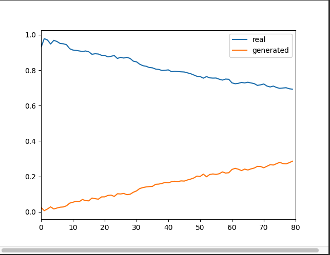

### CNN Discriminator Scores

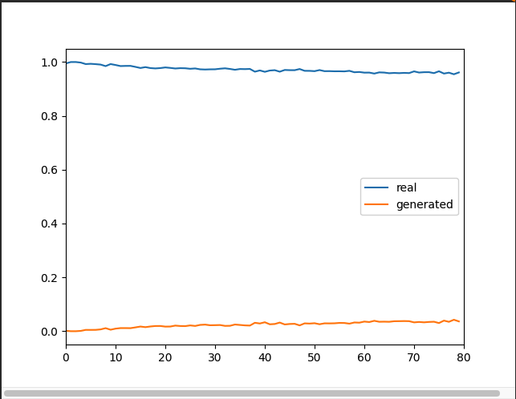

### Generated Examples from MLP Model

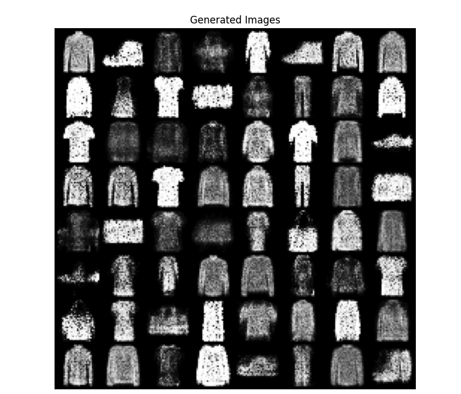

### Generated Examples from CNN

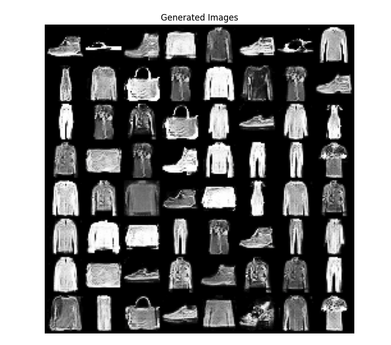

#### Model Definitions

Use these model definitions. **Do not edit this cell for this question. You will first need to run the code cell above containing your answer to question 2.2.**

```python
class MLPGenerator(torch.nn.Module):

    def __init__(self, latent_size: int = 64):
        """Construct a simple MLP generator"""

        super().__init__()

        self.net = torch.nn.Sequential(
            torch.nn.Linear(latent_size, 256),
            torch.nn.ReLU(),
            torch.nn.Linear(256, 256),
            torch.nn.ReLU(),
            torch.nn.Linear(256, 784),
            torch.nn.Sigmoid()
        )

    def forward(self, x: torch.Tensor):

        # reshape generated images to (n_batch, channels, height, width)
        n_batch = x.shape[0]
        return self.net(x).reshape(n_batch, 1, 28, 28)


class MLPDiscriminator(torch.nn.Module):

    def __init__(self):
        """Construct a simple MLP discriminator"""

        super().__init__()

        self.net = torch.nn.Sequential(
            torch.nn.Linear(784, 256),
            torch.nn.LeakyReLU(0.2),
            torch.nn.Linear(256, 256),
            torch.nn.LeakyReLU(0.2),
            torch.nn.Linear(256, 1),
            torch.nn.Sigmoid()
        )

    def forward(self, x: torch.Tensor):

        # flatten input images
        n_batch = x.shape[0]
        x = x.reshape(n_batch, -1)

        return self.net(x)


class MLPGAN(torch.nn.Module):

    def __init__(self, latent_size: int = 64):
        """Construct a simple MLP generative adversarial network"""

        super().__init__()

        self.generator = MLPGenerator(latent_size)
        self.discriminator = MLPDiscriminator()


class NEWGAN(torch.nn.Module):

    def __init__(self, latent_size: int = 64):
        """Construct a generative adversarial network with convolutional discriminator and MLP generator"""

        super().__init__()

        self.generator = MLPGenerator(latent_size)
        self.discriminator = DCDiscriminator()  # this is the discriminator you defined above as part of question 2.2!
```

#### Training Configuration

Use these training hyperparameters. **Do not edit this cell.**

```python
# GAN training hyperparameters
batch_size = 64
latent_size = 64
lr = 0.0002
epochs = 80

# fix random seed
torch.manual_seed(0)

# select device
device = torch.device("cuda" if torch.cuda.is_available() else "cpu")

# load FashionMNIST dataset
data = load_fashionmnist(batch_size=batch_size)

# loss function: binary cross-entropy loss
loss = torch.nn.BCELoss()

# determine which labels will correspond to "real" and "fake" predictions from the discriminator
label_real = 1.0
label_fake = 0.0

# select a fixed set of latent vectors z that we will use to visualize the GAN's generation quality each epoch
fixed_latents = torch.randn((batch_size, latent_size)).to(device)
```

#### Training Loop

**Place your training code in the following cell.**

```python
%load_ext tensorboard
%tensorboard --logdir logs --port 6006
!rm rf ./logs/
run_time = datetime.datetime.now().strftime("%I:%M%p on %B %d, %Y")
logger = SummaryWriter(log_dir=Path("logs") / run_time, flush_secs=20)
```

```python
# initialize the model
# gan = MLPGAN().to(device)
gan = NEWGAN(latent_size=latent_size).to(device)

# use an optimizer to handle parameter updates
opt_discriminator = torch.optim.Adam(gan.discriminator.parameters(), lr=lr)
opt_generator = torch.optim.Adam(gan.generator.parameters(), lr=lr)

################################################################################
# ...YOUR TRAINING CODE HERE
################################################################################
# torch.Size([64, 1, 28, 28])
loss_d = np.zeros(epochs)
loss_g = np.zeros(epochs)
score_real = np.zeros(epochs)
score_fake = np.zeros(epochs)

for epoch in range(epochs):
    iter_count = 0
    for batch_idx, batch_data in enumerate(data):
        x_real, _ = batch_data
        x_real = x_real.to(device)
        n_batch = x_real.shape[0]
        # x_real = x_real.reshape(n_batch, -1) # torch.Size([64, 1, 28, 28]) --> torch.Size([64, 784])

        y_real = torch.full((n_batch, 1), label_real, device=device) # fills n_bathes number of label_real

        #############################################
        # Discriminator
        #############################################

        # Only training every 10 batches for question 3.2
        gan.discriminator.zero_grad()

        preds_real = gan.discriminator(x_real)
        loss_real = loss(preds_real, y_real)

        z = torch.randn(n_batch, latent_size).to(device) # Taking random value from our latent noise vector
        x_fake = gan.generator(z)
        y_fake = torch.full((n_batch, 1), label_fake, device=device)
        preds_fake = gan.discriminator(x_fake.detach())
        loss_fake = loss(preds_fake, y_fake)

        loss_discriminator = loss_real + loss_fake
        loss_discriminator.backward()
        opt_discriminator.step()

        #############################################
        # Generator
        #############################################
        gan.generator.zero_grad()

        z = torch.randn(n_batch, latent_size).to(device)
        x_fake = gan.generator(z)
        preds_fake = gan.discriminator(x_fake)
        loss_generator = loss(preds_fake, y_real)
        loss_generator.backward()

        opt_generator.step()

        loss_d[epoch] += loss_discriminator.detach().item() * n_batch
        loss_g[epoch] += loss_generator.detach().item() * n_batch
        score_real[epoch] += preds_real.mean().detach().item() * n_batch
        score_fake[epoch] += preds_fake.mean().detach().item() * n_batch

        iter_count += n_batch

    loss_d[epoch] /= iter_count
    loss_g[epoch] /= iter_count
    logger.add_image("training_loss", make_loss_plot(epochs, loss_d, loss_g), epoch)


    score_real[epoch] /= iter_count
    score_fake[epoch] /= iter_count
    logger.add_image("discriminator_scores", make_score_plot(epochs, score_real, score_fake), epoch)


    if not epoch % 10:
        print(f"Epoch: {epoch + 1}\tDiscriminator Loss: {loss_d[epoch] :0.4f}\tGenerator Loss: {loss_g[epoch] :0.4f}")

        with torch.no_grad():
            generated = gan.generator(fixed_latents).reshape(batch_size, 1, 28, 28)
            logger.add_image("generated_images", make_grid(generated, math.floor(math.sqrt(batch_size)), title=f"Generated Images (Epoch: {epoch})"), epoch)
```

```
Epoch: 1	Discriminator Loss: 0.0130	Generator Loss: 7.1792
Epoch: 11	Discriminator Loss: 0.0358	Generator Loss: 6.0270
Epoch: 21	Discriminator Loss: 0.0716	Generator Loss: 5.2352
Epoch: 31	Discriminator Loss: 0.0698	Generator Loss: 5.3604
Epoch: 41	Discriminator Loss: 0.0764	Generator Loss: 5.2786
Epoch: 51	Discriminator Loss: 0.0778	Generator Loss: 5.5979
Epoch: 61	Discriminator Loss: 0.0775	Generator Loss: 5.7495
Epoch: 71	Discriminator Loss: 0.0807	Generator Loss: 5.2284
```

```python
generated = gan.generator(fixed_latents).reshape(batch_size, 1, 28, 28)
logger.add_image("generated_images", make_grid(generated, math.floor(math.sqrt(batch_size)), title="Generated Images"), epoch)
```

## Question 3: Mode Collapse (four points total)

GANs are notoriously difficult to train, as they involve a "competitive game" between two or more networks with multiple alternating update steps. In fact, there is a large volume of research addressing well-know GAN bugs ("*failure modes*"). In this question, we'll look at one in particular: *mode collapse*.

### **3.1** Latent Dimension (two points)

Mode collapse occurs when a GAN learns to produce only a small set of similar outputs. We can think of these outputs as *modes* in the data distribution, "peaks" in the likelihood function that correspond to realistic samples. To a certain extent, we want our GAN to focus on high-likelihood regions of the data space in order to produce realistic examples. However, we want our GAN to learn to sample from the entire data distribution -- not just a few points.

The figure below illustrates this phenomenon. Ideally, when we sample generator inputs from the noise ("latent") distribution $p(z)$, our GAN will produce realistic (high-likelihood) images in the data distribution $p(x)$ (third image). If we don't train our GAN well, it might fail to focus on high-likelihood regions of the data distribution and frequently output random noise (first image). If our GAN suffers from mode collapse, it will map all noise inputs to only a few high-likelihood points in the data distribution (second image).

[figure not shown]

Mode collapse can occur for a variety of reasons, especially in large and complex networks. Given the simplicity of our GAN architecture, we'll start with a simple example. **Train a `NEWGAN` model with a generator input dimension (`latent_size`) of 1 on FashionMNIST for 80 epochs (you will have to modify your training code so that generator inputs have size 1). Include an image of a batch of generated images below. Explain how this modification of the GAN architecture is (or isn't) reflected in your results.**

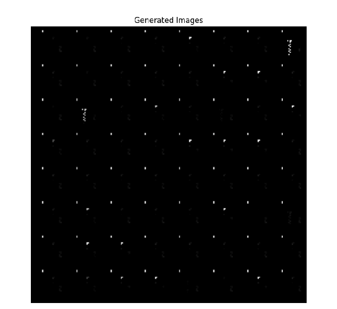

This modification of the GAN architecture is clearly reflected in the results. We can see clearly that the generator was unable to learn complex relationships within the data, this is largely due to the smaller number of dimensions unable to capture clear patterns in the data. Our generator clearly learned to fixate on a specific dot rather than what actually makes certain images the way that they are.

### **3.2** Update Schedule (two points)

In some situations, it is necessary to update the generator and discriminator networks on different schedules (i.e. not just in alternating turns every batch). However, a poorly-chosen update schedule may lead to mode collapse.

**Train a `NEWGAN` model with `latent_size`=64 for 80 epochs, but modify your training code to only update the discriminator every *ten* batches. Include both a discriminator scores plot and a batch of generated images below. Finally, explain why your change to the GAN's training schedule did or did not cause a notable change in its output (compared to the original `NEWGAN`).** *Hint: you may want to look at how your generated images evolve over time.*

Discriminator Scores (only trained every 10 batches)

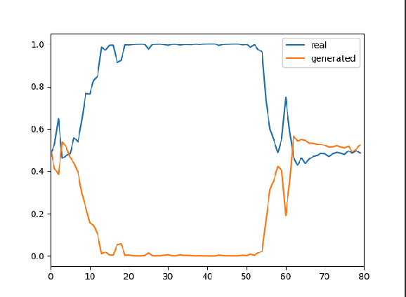

Generated Images (discriminator only updated every 10 batches) (mode collapse)

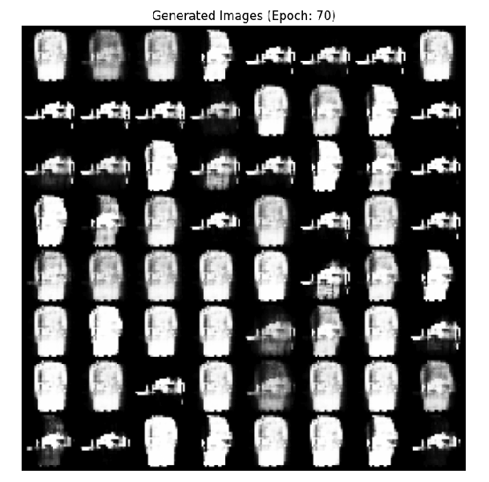

My change to the GAN's training schedule did cause a notable change in its output. This has to do directly with Mode Collapse and what is mentioned directly in the textbook: "D must be synchronized well with G during training...G must not be trained too much without updating D... [otherwise] G collapses too many values of z to the same value of x..." (Page 7 of Generative Adversarial Nets - Goodfellow). Because the generator learns from the discriminator and not the true data, without as many points to learn from the discriminator, the generator has trouble effectively learning from the data distribution, and continues to create very similar outputs.

## Question 4 (four points total)

GANs generate by mapping latent noise vectors to synthetic instances. In [notebook 6](https://github.com/interactiveaudiolab/course-deep-learning/blob/main/notebooks/notebook_6_gan.ipynb), we saw that we could perform an "inverse" mapping from a real image to a corresponding latent vector using aversarial-example-like optimization. This lets us do cool things, like smoothly interpolating between images.

### **4.1** Finding Latents (two points)

**Find which numeric labels correspond to the FashionMNIST classes for "sneaker" and "handbag." Select one instance of each class. Then, using your "best" trained `NEWGAN` model from the questions above and the method outlined in notebook 6, compute a latent vector corresponding to each instance. Finally, pass each latent vector through the generator network to obtain a "reconstruction" of each instance.** *Hint: you may want to implement a learning rate and adjust the number of iterations for your reconstructions.*

```python
# NOTE: I wasn't sure if you wanted extra code for both the 4.1 and 4.2 questions.
# I simplified it only to show 4.2 code because it is very similar to what I did for 4.1, just this one
# includes latent walks progression.

def train_z_vector(z_vector, target_batch):
    """
    Gradient descent on a latent vector, z based on a target.

    Returns an array of the image progression over each 100 training steps.
    """
    optimizer = torch.optim.Adam([z_vector], lr=0.035) # https://pytorch.org/docs/stable/optim.html
    loss_function = torch.nn.MSELoss()

    image_progression = []
    for i in range(1000):
        z_vector.grad = None

        # Your code is doing MSE more manually, I am going to pass it into pytorch instead for readability
        outputs = gan.generator(z_vector)
        loss = loss_function(outputs, target_batch)
        loss.backward()
        grad = z_vector.grad.detach()
        optimizer.step()

        if not i % 100:
            # print(f"Iteration: {i}; Loss: {loss.item()}")
            image_reconstructed = outputs.detach().cpu().reshape(28, 28)
            image_progression.append((image_reconstructed, i))
    return image_progression

def plot_progression(image_progression, target_batch=None, flag=False):
    """Plots the latent walk"""

    if target_batch is not None:
        print("Original Image:")
        plt.imshow(target_batch.reshape(28, 28), cmap='gray')
        plt.show()

        fig, axes = plt.subplots(1, len(image_progression), figsize=(15, 15))
        for j, ax in enumerate(axes):
            ax.imshow(image_progression[j][0], cmap='gray')
            ax.set_title(f"Epoch: {image_progression[j][1]}")
            ax.axis('off')
        plt.show()
    else:
        fig, axes = plt.subplots(1, len(image_progression), figsize=(15, 15))
        for j, ax in enumerate(axes):
            ax.imshow(image_progression[j], cmap='gray')
            ax.axis('off')

            if flag:
                if j == 0:
                    ax.set_title("Original Sneaker", fontsize=12)
                elif j == len(image_progression) - 1:
                    ax.set_title("Original Handbag", fontsize=12)
                else:
                     ax.set_title("Interpolated", fontsize=12)


        plt.show()
```

```python
batch, labels = next(iter(data))

#########################################
# TRAINING THE SNEAKER Z VECTOR
#########################################

sneaker_z_vector = torch.randn(1, latent_size).to(device).requires_grad_(True)

target_batch_raw = batch[(labels == 7)][0]
target_batch = target_batch_raw.to(device).unsqueeze(1)

sneaker_training_progression = train_z_vector(sneaker_z_vector, target_batch)

plot_progression(sneaker_training_progression, target_batch_raw)
```

```python
#########################################
# TRAINING THE HANDBAG Z VECTOR
#########################################

handbag_z_vector = torch.randn(1, latent_size).to(device).requires_grad_(True)

target_batch_raw = batch[(labels == 8)][0]
target_batch = target_batch_raw.to(device).unsqueeze(1)

handbag_training_progression = train_z_vector(handbag_z_vector, target_batch)

plot_progression(handbag_training_progression, target_batch_raw)
```

```python
#########################################
# INTERPOLATING BETWEEN SNEAKER TO HANDBAG
#########################################

image_progression = [sneaker_training_progression[-1][0]] # First element is my trained sneaker image

for i in range(50):
    point = (i / 10) * (handbag_z_vector - sneaker_z_vector) + sneaker_z_vector
    img = gan.generator(point).view(28, 28)
    img_cpu = img.cpu().detach().numpy()
    image_progression.append(img_cpu)

cherry_pick = [0, 4, 11, 25, 49]
image_progression = [img for i, img in enumerate(image_progression) if i in cherry_pick]
image_progression.append(handbag_training_progression[-1][0])

plot_progression(image_progression, flag=True)
```

Original Images

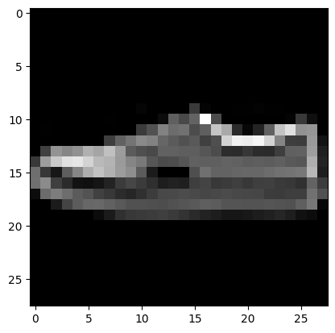

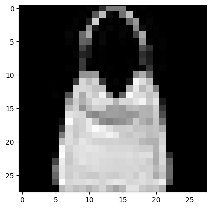

Reconstructed Images

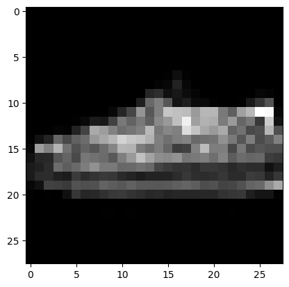

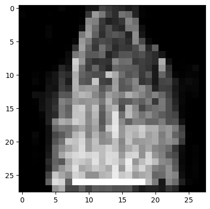

### **4.2** Interpolating Between Latents (two points)

Notebook 6 describes how to visualize a smooth interpolation between latent vectors. **Do the same here, but instead of a video, save and include *four* "intermediate" images as you interpolate between the two latent vectors you generated in question 4.1.** If you want a "smoother" interpolation, you can simply generate more intermediate images and cherry-pick four that illustrate the progression from one instance to the other.

Interpolation

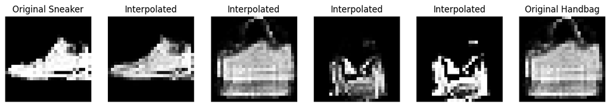